# Between sample/beta diversity of Microbes by gut section

Calla Bush St George

2025-08-13

# Goals

1. Load in phyloseq data with rooted tree.
2. Evaluate sequencing depth and remove sample.
3. Normalize the read counts between samples.
4. Calculate community dissimilarities. Numbers between 0 and 1. If 0, completely similar versus if they are 1, then they are completely dissimilar.
   1. *Sorensen*: Presence/ Absence. Weighted by number of shared taxa. Shared species as a binary-valye. Abundance-unweighted.
   2. *Bray-Curtis*: Relative abundance. Weighted by number of shared taxa. Shared abundant species: abundance weighted.
   3. *(Abundance) Weighted UNIFRAC*: Consider abundant species and where they fall on the tree.
5. Visualize the community data with two unconstricted ordinations:
   1. *PCoA*: Linear method. Uses matrix algebra to calculate eigenvalye. Calculate how much variation is explained by each axis. Can choose to view axis 1, 2, 3, etc. and plot them together.
   2. *NMDS*: Non-linear method. Collapse multiple axes into two (or three) dimensions. Can see more axes of variation into fewer axes. Always need to report a stress value. (Ideally less than 0.15)
6. Run statistics with PERMANOVA and betadispR.

# Setup

## Load Libraries

```r
# Install packages if needed

pacman::p_load(tidyverse, devtools, phyloseq, patchwork, vegan, ggpubr, rstatix,
               ggplot2,install = FALSE)
```

## Load in colors

```r
gut_section_colors <- c(
  "Midgut" = "dodgerblue4",
  "Hindgut" = "#FF5733")
```

## Load in data

```r
# Load in rooted phylogenetic tree!
load("data/03_Phylogenetic_Tree/phytree_preprocessed_physeq.RData")
unrooted_physeq
```

```
## phyloseq-class experiment-level object
## otu_table()   OTU Table:         [ 147 taxa and 9 samples ]
## sample_data() Sample Data:       [ 9 samples by 26 sample variables ]
## tax_table()   Taxonomy Table:    [ 147 taxa by 9 taxonomic ranks ]
## phy_tree()    Phylogenetic Tree: [ 147 tips and 145 internal nodes ]
```

```r
midroot_physeq
```

```
## phyloseq-class experiment-level object
## otu_table()   OTU Table:         [ 147 taxa and 9 samples ]
## sample_data() Sample Data:       [ 9 samples by 26 sample variables ]
## tax_table()   Taxonomy Table:    [ 147 taxa by 9 taxonomic ranks ]
## phy_tree()    Phylogenetic Tree: [ 147 tips and 146 internal nodes ]
```

# Explore Read Counts

## Raw Read Depth

```r
# Sequence depth will inform us on how we want to normalize our data
# Calculate the total number of reads per sample
raw_total_seqs_df <-
  unrooted_physeq %>%
  # Calculate the sample read sums
  sample_sums() %>%
  data.frame()

# Name the column
colnames(raw_total_seqs_df)[1] <- "TotalSeqs"

head(raw_total_seqs_df)
```

```
##            TotalSeqs
## ERR3585831      1627
## ERR3585834      2891
## ERR3585835     39091
## ERR3585837     46788
## ERR3585838     65571
## ERR3585840      4114
```

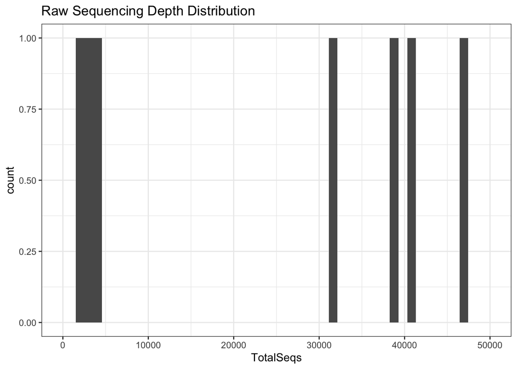

```r
# Make a histogram of raw reads
raw_seqs_histogram <-
  raw_total_seqs_df %>%
  ggplot(aes(x = TotalSeqs)) +
  geom_histogram(bins = 50) +
  scale_x_continuous(limits = c(0, 50000)) +
  labs(title = "Raw Sequencing Depth Distribution") +
  theme_bw()

raw_seqs_histogram
```